# Data Modelling & Evaluation

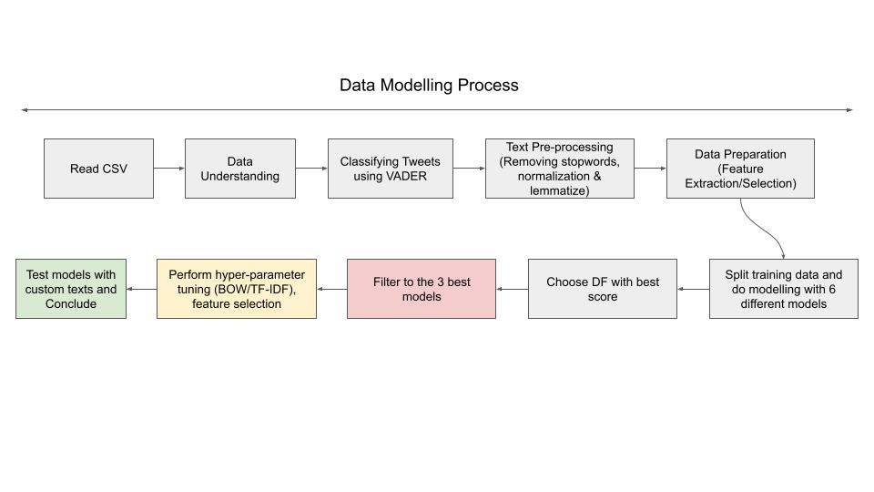

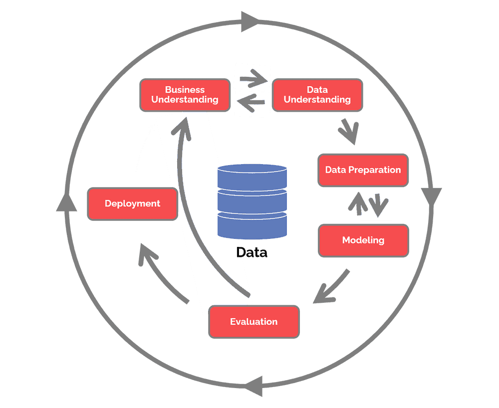

```python
import numpy as np
import pandas as pd
import matplotlib.pyplot as plt
import seaborn as sns
import nltk
import re
```

```python
# Read merged dataset

df = pd.read_csv('merged_group_data.csv')
```

```python
df
```

|  | Headlines |
| --- | --- |
| 0 | Sequoia-backed DeFi app Flint discontinues fla... |
| 1 | Dutch central bank fines cryptocurrency exchan... |
| 2 | Crypto is worth fixing. Regulators should get ... |
| 3 | Cryptocurrency roundup for January 26: Circle'... |
| 4 | Cryptocurrency roundup for January 25: Binance... |
| ... | ... |
| 2589 | Commodity ETF providers aim for green niche |
| 2590 | Lord make me ESG, but not yet |
| 2591 | Ken Griffin’s Citadel Securities borrows $600m... |
| 2592 | US stocks edge higher after burst of mixed eco... |
| 2593 | Companies burnt through a record amount of cas... |

2594 rows × 1 columns

```python
print("Total number of rows in Dataframe:", df.shape[0])
```

```
Total number of rows in Dataframe: 2594
```

```python
df.info()
```

```
<class 'pandas.core.frame.DataFrame'>
RangeIndex: 2594 entries, 0 to 2593
Data columns (total 1 columns):
 #   Column     Non-Null Count  Dtype
---  ------     --------------  -----
 0   Headlines  2594 non-null   object
dtypes: object(1)
memory usage: 20.4+ KB
```

```python
df.describe()
```

|  | Headlines |
| --- | --- |
| count | 2594 |
| unique | 1897 |
| top | Russia's war on Ukraine latest: Battling in Do... |
| freq | 80 |

```python
duplicate_rows = df.duplicated()
print("Number of duplicate rows: ", duplicate_rows.sum())
```

```
Number of duplicate rows:  697
```

```python
# Drop duplicates
df = df.drop_duplicates()
```

```python
print("Total number of rows in Dataframe:", df.shape[0])
```

```
Total number of rows in Dataframe: 1897
```

```python
# Clean the dataframe

# Define a regular expression pattern to match special characters
pattern = r'[^a-zA-Z0-9\s]'
# Use the `re.sub()` function to remove special characters and numbers
df['Filtered_Headlines'] = df['Headlines'].apply(lambda x: re.sub(pattern, '', x))

# remove empty rows
#df = df.dropna()
df.dropna(inplace = True) # remove empty rows
```

```python
df.head(10)
```

|  | Headlines | Filtered_Headlines |
| --- | --- | --- |
| 0 | Sequoia-backed DeFi app Flint discontinues fla... | Sequoiabacked DeFi app Flint discontinues flag... |
| 1 | Dutch central bank fines cryptocurrency exchan... | Dutch central bank fines cryptocurrency exchan... |
| 2 | Crypto is worth fixing. Regulators should get ... | Crypto is worth fixing Regulators should get m... |
| 3 | Cryptocurrency roundup for January 26: Circle'... | Cryptocurrency roundup for January 26 Circles ... |
| 4 | Cryptocurrency roundup for January 25: Binance... | Cryptocurrency roundup for January 25 Binance ... |
| 5 | Top Cryptocurrency Prices Today January 25: Bi... | Top Cryptocurrency Prices Today January 25 Bit... |
| 6 | Cryptocurrency roundup for January 24: Cardano... | Cryptocurrency roundup for January 24 Cardano ... |
| 7 | Top Cryptocurrency Prices Today January 24: Bi... | Top Cryptocurrency Prices Today January 24 Bit... |
| 8 | Top Cryptocurrency Prices Today January 23: Ma... | Top Cryptocurrency Prices Today January 23 Maj... |
| 9 | Bitcoin rises 2.3% to $23,199 | Bitcoin rises 23 to 23199 |

```python
print("Total number of rows in Dataframe:", df.shape[0])
```

```
Total number of rows in Dataframe: 1897
```

# Classify Tweets using VADER

#### Using Comp score metric that calculates sum of lexicon rataings, normalized between -1(most negative) and +1 (most positive)

```python
from vaderSentiment.vaderSentiment import SentimentIntensityAnalyzer
```

```python
#Vader_Sentiment	Tokenized_headlines	Stemmed_Headlines	POS_Tags	Filtered_Headlines

def sentiment_vader(text):
    over_all_polarity = sid.polarity_scores(text)
    if over_all_polarity['compound'] >= 0.05:
        return "positive"
    elif over_all_polarity['compound'] <= -0.05:
        return "negative"
    else:
        return "neutral"
```

```python
sid = SentimentIntensityAnalyzer()
```

```python
# Create new column to show polarity of tweets
df['Vader_Sentiment'] = df['Filtered_Headlines'].apply(lambda x: sentiment_vader(x))
```

```python
df.head(30)
```

|  | Headlines | Filtered_Headlines | Vader_Sentiment |
| --- | --- | --- | --- |
| 0 | Sequoia-backed DeFi app Flint discontinues fla... | Sequoiabacked DeFi app Flint discontinues flag... | positive |
| 1 | Dutch central bank fines cryptocurrency exchan... | Dutch central bank fines cryptocurrency exchan... | neutral |
| 2 | Crypto is worth fixing. Regulators should get ... | Crypto is worth fixing Regulators should get m... | positive |
| 3 | Cryptocurrency roundup for January 26: Circle'... | Cryptocurrency roundup for January 26 Circles ... | negative |
| 4 | Cryptocurrency roundup for January 25: Binance... | Cryptocurrency roundup for January 25 Binance ... | neutral |
| 5 | Top Cryptocurrency Prices Today January 25: Bi... | Top Cryptocurrency Prices Today January 25 Bit... | positive |
| 6 | Cryptocurrency roundup for January 24: Cardano... | Cryptocurrency roundup for January 24 Cardano ... | positive |
| 7 | Top Cryptocurrency Prices Today January 24: Bi... | Top Cryptocurrency Prices Today January 24 Bit... | positive |
| 8 | Top Cryptocurrency Prices Today January 23: Ma... | Top Cryptocurrency Prices Today January 23 Maj... | positive |
| 9 | Bitcoin rises 2.3% to $23,199 | Bitcoin rises 23 to 23199 | neutral |
| 10 | Bankman-Fried assets of almost $700 million ma... | BankmanFried assets of almost 700 million may ... | negative |
| 11 | U.S. to announce international cryptocurrency ... | US to announce international cryptocurrency ac... | neutral |
| 12 | Crypto exchange Coinbase says to halt operatio... | Crypto exchange Coinbase says to halt operatio... | neutral |
| 13 | FTX reports $415 million in hacked crypto, Ban... | FTX reports 415 million in hacked crypto Bankm... | negative |
| 14 | Top cryptocurrency news on January 18: How reg... | Top cryptocurrency news on January 18 How regu... | positive |
| 15 | Top Cryptocurrency Prices Today January 18: Ma... | Top Cryptocurrency Prices Today January 18 Maj... | positive |
| 16 | FTX says $415 million in crypto was hacked | FTX says 415 million in crypto was hacked | negative |
| 17 | Top cryptocurrency news on January 17: Shiba I... | Top cryptocurrency news on January 17 Shiba In... | negative |
| 18 | Davos 2023: Accenture Executive David Treat sa... | Davos 2023 Accenture Executive David Treat say... | positive |
| 19 | Top Cryptocurrency Prices Today January 17: Bi... | Top Cryptocurrency Prices Today January 17 Bit... | positive |
| 20 | Budget 2023: Expect some tighter regulations f... | Budget 2023 Expect some tighter regulations fo... | neutral |
| 21 | Cryptocurrency roundup for January 16: Cathie ... | Cryptocurrency roundup for January 16 Cathie W... | negative |
| 22 | Top Cryptocurrency Prices Today January 16: Bi... | Top Cryptocurrency Prices Today January 16 Bit... | positive |
| 23 | Bitcoin smashes $21,000 ceiling; experts weigh... | Bitcoin smashes 21000 ceiling experts weigh in... | neutral |
| 24 | Crypto mCap surpasses $1 trillion mark first t... | Crypto mCap surpasses 1 trillion mark first ti... | neutral |
| 25 | Bitcoin surges above $21,000 amid optimism aro... | Bitcoin surges above 21000 amid optimism aroun... | positive |
| 26 | When terminator robots police loan markets | When terminator robots police loan markets | neutral |
| 27 | Crypto winter triggers avalanche of layoffs in... | Crypto winter triggers avalanche of layoffs in... | negative |
| 28 | 'I didn't steal funds': 10 quotes from Sam Ban... | I didnt steal funds 10 quotes from Sam Bankman... | neutral |
| 29 | Cryptocurrency roundup for January 13: Hong Ko... | Cryptocurrency roundup for January 13 Hong Kon... | positive |

```python
print("\n\nVADER Sentiments")
classification_counts = df['Vader_Sentiment'].value_counts()
print("Positive: ", classification_counts['positive'])
print("Neutral: ", classification_counts['neutral'])
print("Negative: ", classification_counts['negative'])

#Print total number of rows
print("Total number of rows in Vader_Sentiment Column: ",df['Vader_Sentiment'].shape[0])
```

```
VADER Sentiments
Positive:  540
Neutral:  811
Negative:  546
Total number of rows in Vader_Sentiment Column:  1897
```

```python
# Change neutral to positive

def change_neutral_to_positive(sentiment):
    if sentiment == "neutral":
        return "positive"
    else:
        return sentiment

df['Vader_Sentiment'] = df['Vader_Sentiment'].apply(change_neutral_to_positive)
```

```python
# Count number of positives,neutrals and negatives
print("VADER Sentiments")
classification_counts = df['Vader_Sentiment'].value_counts()
print("Positive: ", classification_counts['positive'])
print("Negative: ", classification_counts['negative'])

#Print total number of rows
print("\nTotal number of rows in Vader_Sentiment Column: ",df['Vader_Sentiment'].shape[0])
```

```
VADER Sentiments
Positive:  1351
Negative:  546

Total number of rows in Vader_Sentiment Column:  1897
```

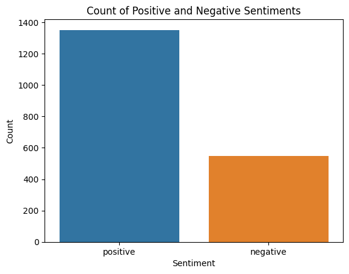

```python
# Plot the count of positive and negative values using countplot
sns.countplot(x='Vader_Sentiment', data=df)

# Add labels and title to the chart
plt.xlabel('Sentiment')
plt.ylabel('Count')
plt.title('Count of Positive and Negative Sentiments')

# Show the chart
plt.show()
```

## Data Preprocessing

We will begin with data preprocessing with the following pipeline:

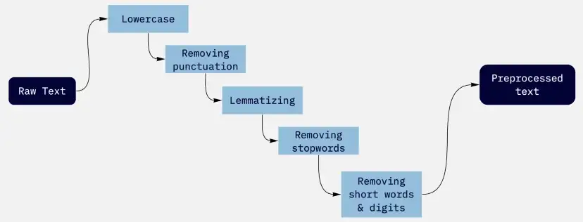

```python
# Download the necessary NLTK packages
nltk.download('punkt')
nltk.download('wordnet')
nltk.download('averaged_perceptron_tagger')
nltk.download('stopwords')
```

```
True
```

```python
# Import the necessary libraries
from nltk.tokenize import word_tokenize, sent_tokenize
from nltk.stem import PorterStemmer, WordNetLemmatizer
from nltk.tag import pos_tag
from nltk.corpus import stopwords
from nltk.tokenize import RegexpTokenizer
from nltk.stem import SnowballStemmer
from nltk.tag import pos_tag

from nltk.util import ngrams
from nltk.tag import pos_tag
from nltk.tokenize import MWETokenizer


from sklearn.feature_extraction.text import CountVectorizer
from sklearn.feature_extraction.text import TfidfVectorizer
from sklearn.metrics.pairwise import cosine_similarity
```

# Data Cleaning (Pre-Processing)

```python
# Create new dataframe df1 to do more pre-processing
df1 = pd.DataFrame(df)
```

```python
df1.head()
```

|  | Headlines | Filtered_Headlines | Vader_Sentiment |
| --- | --- | --- | --- |
| 0 | Sequoia-backed DeFi app Flint discontinues fla... | Sequoiabacked DeFi app Flint discontinues flag... | positive |
| 1 | Dutch central bank fines cryptocurrency exchan... | Dutch central bank fines cryptocurrency exchan... | positive |
| 2 | Crypto is worth fixing. Regulators should get ... | Crypto is worth fixing Regulators should get m... | positive |
| 3 | Cryptocurrency roundup for January 26: Circle'... | Cryptocurrency roundup for January 26 Circles ... | negative |
| 4 | Cryptocurrency roundup for January 25: Binance... | Cryptocurrency roundup for January 25 Binance ... | positive |

```python
# Removing special characters & numbers
# Define a regular expression pattern to match special characters and numbers
pattern = r'[^a-zA-Z\s]'

# Use the `re.sub()` function to remove special characters and numbers
df1['Filtered_Headlines'] = df1['Headlines'].apply(lambda x: re.sub(pattern, '', x))

# remove empty rows
df.dropna(inplace = True)
```

```python
# Tokenization
df1['Tokenized_headlines'] = df['Filtered_Headlines'].apply(lambda x: word_tokenize(x))
df1.head()
```

|  | Headlines | Filtered_Headlines | Vader_Sentiment | Tokenized_headlines |
| --- | --- | --- | --- | --- |
| 0 | Sequoia-backed DeFi app Flint discontinues fla... | Sequoiabacked DeFi app Flint discontinues flag... | positive | [Sequoiabacked, DeFi, app, Flint, discontinues... |
| 1 | Dutch central bank fines cryptocurrency exchan... | Dutch central bank fines cryptocurrency exchan... | positive | [Dutch, central, bank, fines, cryptocurrency, ... |
| 2 | Crypto is worth fixing. Regulators should get ... | Crypto is worth fixing Regulators should get m... | positive | [Crypto, is, worth, fixing, Regulators, should... |
| 3 | Cryptocurrency roundup for January 26: Circle'... | Cryptocurrency roundup for January Circles b... | negative | [Cryptocurrency, roundup, for, January, Circle... |
| 4 | Cryptocurrency roundup for January 25: Binance... | Cryptocurrency roundup for January Binance pr... | positive | [Cryptocurrency, roundup, for, January, Binanc... |

```python
# download the stopwords
stop_words = set(stopwords.words('english'))
```

```python
# Removing stopwords
df1['Tokenized_headlines'] = df1['Tokenized_headlines'].apply(lambda x: [word for word in x if word.lower() not in stop_words])
df1.head()
```

|  | Headlines | Filtered_Headlines | Vader_Sentiment | Tokenized_headlines |
| --- | --- | --- | --- | --- |
| 0 | Sequoia-backed DeFi app Flint discontinues fla... | Sequoiabacked DeFi app Flint discontinues flag... | positive | [Sequoiabacked, DeFi, app, Flint, discontinues... |
| 1 | Dutch central bank fines cryptocurrency exchan... | Dutch central bank fines cryptocurrency exchan... | positive | [Dutch, central, bank, fines, cryptocurrency, ... |
| 2 | Crypto is worth fixing. Regulators should get ... | Crypto is worth fixing Regulators should get m... | positive | [Crypto, worth, fixing, Regulators, get, moving] |
| 3 | Cryptocurrency roundup for January 26: Circle'... | Cryptocurrency roundup for January Circles b... | negative | [Cryptocurrency, roundup, January, Circles, bi... |
| 4 | Cryptocurrency roundup for January 25: Binance... | Cryptocurrency roundup for January Binance pr... | positive | [Cryptocurrency, roundup, January, Binance, pr... |

```python
# convert to lower case
df1['Tokenized_headlines'] = df1['Tokenized_headlines'].apply(lambda x: [word.lower() for word in x])
df1.head()
```

|  | Headlines | Filtered_Headlines | Vader_Sentiment | Tokenized_headlines |
| --- | --- | --- | --- | --- |
| 0 | Sequoia-backed DeFi app Flint discontinues fla... | Sequoiabacked DeFi app Flint discontinues flag... | positive | [sequoiabacked, defi, app, flint, discontinues... |
| 1 | Dutch central bank fines cryptocurrency exchan... | Dutch central bank fines cryptocurrency exchan... | positive | [dutch, central, bank, fines, cryptocurrency, ... |
| 2 | Crypto is worth fixing. Regulators should get ... | Crypto is worth fixing Regulators should get m... | positive | [crypto, worth, fixing, regulators, get, moving] |
| 3 | Cryptocurrency roundup for January 26: Circle'... | Cryptocurrency roundup for January Circles b... | negative | [cryptocurrency, roundup, january, circles, bi... |
| 4 | Cryptocurrency roundup for January 25: Binance... | Cryptocurrency roundup for January Binance pr... | positive | [cryptocurrency, roundup, january, binance, pr... |

```python
# Stemming
# Create a new Porter stemmer object
stemmer = PorterStemmer()

# Use the apply() method to stem the words
df1['Stemmed_Headlines'] = df1['Tokenized_headlines'].apply(lambda x: [stemmer.stem(word) for word in x])
df1.head(10)
```

|  | Headlines | Filtered_Headlines | Vader_Sentiment | Tokenized_headlines | Stemmed_Headlines |
| --- | --- | --- | --- | --- | --- |
| 0 | Sequoia-backed DeFi app Flint discontinues fla... | Sequoiabacked DeFi app Flint discontinues flag... | positive | [sequoiabacked, defi, app, flint, discontinues... | [sequoiaback, defi, app, flint, discontinu, fl... |
| 1 | Dutch central bank fines cryptocurrency exchan... | Dutch central bank fines cryptocurrency exchan... | positive | [dutch, central, bank, fines, cryptocurrency, ... | [dutch, central, bank, fine, cryptocurr, excha... |
| 2 | Crypto is worth fixing. Regulators should get ... | Crypto is worth fixing Regulators should get m... | positive | [crypto, worth, fixing, regulators, get, moving] | [crypto, worth, fix, regul, get, move] |
| 3 | Cryptocurrency roundup for January 26: Circle'... | Cryptocurrency roundup for January Circles b... | negative | [cryptocurrency, roundup, january, circles, bi... | [cryptocurr, roundup, januari, circl, billion,... |
| 4 | Cryptocurrency roundup for January 25: Binance... | Cryptocurrency roundup for January Binance pr... | positive | [cryptocurrency, roundup, january, binance, pr... | [cryptocurr, roundup, januari, binanc, process... |
| 5 | Top Cryptocurrency Prices Today January 25: Bi... | Top Cryptocurrency Prices Today January Bitco... | positive | [top, cryptocurrency, prices, today, january, ... | [top, cryptocurr, price, today, januari, bitco... |
| 6 | Cryptocurrency roundup for January 24: Cardano... | Cryptocurrency roundup for January Cardano hi... | positive | [cryptocurrency, roundup, january, cardano, hi... | [cryptocurr, roundup, januari, cardano, hit, g... |
| 7 | Top Cryptocurrency Prices Today January 24: Bi... | Top Cryptocurrency Prices Today January Bitco... | positive | [top, cryptocurrency, prices, today, january, ... | [top, cryptocurr, price, today, januari, bitco... |
| 8 | Top Cryptocurrency Prices Today January 23: Ma... | Top Cryptocurrency Prices Today January Major... | positive | [top, cryptocurrency, prices, today, january, ... | [top, cryptocurr, price, today, januari, major... |
| 9 | Bitcoin rises 2.3% to $23,199 | Bitcoin rises to | positive | [bitcoin, rises] | [bitcoin, rise] |

```python
# Lemmatization
# Initialize the lemmatizer
lemmatizer = WordNetLemmatizer()

# Define a function to apply the lemmatization to each word in a list
def lemmatize_text(text):
    return [lemmatizer.lemmatize(word) for word in text]

# Lemmatize the tokenized headlines
df1['Lemmatized_Headlines'] = df1['Stemmed_Headlines'].apply(lemmatize_text)
df1.head()
```

|  | Headlines | Filtered_Headlines | Vader_Sentiment | Tokenized_headlines | Stemmed_Headlines | Lemmatized_Headlines |
| --- | --- | --- | --- | --- | --- | --- |
| 0 | Sequoia-backed DeFi app Flint discontinues fla... | Sequoiabacked DeFi app Flint discontinues flag... | positive | [sequoiabacked, defi, app, flint, discontinues... | [sequoiaback, defi, app, flint, discontinu, fl... | [sequoiaback, defi, app, flint, discontinu, fl... |
| 1 | Dutch central bank fines cryptocurrency exchan... | Dutch central bank fines cryptocurrency exchan... | positive | [dutch, central, bank, fines, cryptocurrency, ... | [dutch, central, bank, fine, cryptocurr, excha... | [dutch, central, bank, fine, cryptocurr, excha... |
| 2 | Crypto is worth fixing. Regulators should get ... | Crypto is worth fixing Regulators should get m... | positive | [crypto, worth, fixing, regulators, get, moving] | [crypto, worth, fix, regul, get, move] | [crypto, worth, fix, regul, get, move] |
| 3 | Cryptocurrency roundup for January 26: Circle'... | Cryptocurrency roundup for January Circles b... | negative | [cryptocurrency, roundup, january, circles, bi... | [cryptocurr, roundup, januari, circl, billion,... | [cryptocurr, roundup, januari, circl, billion,... |
| 4 | Cryptocurrency roundup for January 25: Binance... | Cryptocurrency roundup for January Binance pr... | positive | [cryptocurrency, roundup, january, binance, pr... | [cryptocurr, roundup, januari, binanc, process... | [cryptocurr, roundup, januari, binanc, process... |

```python
# POS (Parts of Speech) Tagging
df1['POS_Tags'] = df1['Lemmatized_Headlines'].apply(nltk.pos_tag)
df1.head()
```

|  | Headlines | Filtered_Headlines | Vader_Sentiment | Tokenized_headlines | Stemmed_Headlines | Lemmatized_Headlines | POS_Tags |
| --- | --- | --- | --- | --- | --- | --- | --- |
| 0 | Sequoia-backed DeFi app Flint discontinues fla... | Sequoiabacked DeFi app Flint discontinues flag... | positive | [sequoiabacked, defi, app, flint, discontinues... | [sequoiaback, defi, app, flint, discontinu, fl... | [sequoiaback, defi, app, flint, discontinu, fl... | [(sequoiaback, NN), (defi, NN), (app, NN), (fl... |
| 1 | Dutch central bank fines cryptocurrency exchan... | Dutch central bank fines cryptocurrency exchan... | positive | [dutch, central, bank, fines, cryptocurrency, ... | [dutch, central, bank, fine, cryptocurr, excha... | [dutch, central, bank, fine, cryptocurr, excha... | [(dutch, JJ), (central, JJ), (bank, NN), (fine... |
| 2 | Crypto is worth fixing. Regulators should get ... | Crypto is worth fixing Regulators should get m... | positive | [crypto, worth, fixing, regulators, get, moving] | [crypto, worth, fix, regul, get, move] | [crypto, worth, fix, regul, get, move] | [(crypto, NN), (worth, JJ), (fix, NN), (regul,... |
| 3 | Cryptocurrency roundup for January 26: Circle'... | Cryptocurrency roundup for January Circles b... | negative | [cryptocurrency, roundup, january, circles, bi... | [cryptocurr, roundup, januari, circl, billion,... | [cryptocurr, roundup, januari, circl, billion,... | [(cryptocurr, NN), (roundup, NN), (januari, NN... |
| 4 | Cryptocurrency roundup for January 25: Binance... | Cryptocurrency roundup for January Binance pr... | positive | [cryptocurrency, roundup, january, binance, pr... | [cryptocurr, roundup, januari, binanc, process... | [cryptocurr, roundup, januari, binanc, process... | [(cryptocurr, NN), (roundup, NN), (januari, NN... |

## Creating new cleaned dataset to remove columns

```python
df_cleaned = pd.DataFrame(df1)
```

```python
df_cleaned = df_cleaned.drop(columns='Headlines')
df_cleaned = df_cleaned.drop(columns='Filtered_Headlines')
df_cleaned = df_cleaned.drop(columns='Tokenized_headlines')
df_cleaned = df_cleaned.drop(columns='Stemmed_Headlines')
```

```python
df_cleaned.head()
```

|  | Vader_Sentiment | Lemmatized_Headlines | POS_Tags |
| --- | --- | --- | --- |
| 0 | positive | [sequoiaback, defi, app, flint, discontinu, fl... | [(sequoiaback, NN), (defi, NN), (app, NN), (fl... |
| 1 | positive | [dutch, central, bank, fine, cryptocurr, excha... | [(dutch, JJ), (central, JJ), (bank, NN), (fine... |
| 2 | positive | [crypto, worth, fix, regul, get, move] | [(crypto, NN), (worth, JJ), (fix, NN), (regul,... |
| 3 | negative | [cryptocurr, roundup, januari, circl, billion,... | [(cryptocurr, NN), (roundup, NN), (januari, NN... |
| 4 | positive | [cryptocurr, roundup, januari, binanc, process... | [(cryptocurr, NN), (roundup, NN), (januari, NN... |

```python
# Moving df_cleaned to outer column
# Get the current columns in the dataframe
cols = df_cleaned.columns.tolist()

# Remove "Vader_Sentiment" from its current position
cols.remove("Vader_Sentiment")

# Add "Vader_Sentiment" back to the end of the list
cols.append("Vader_Sentiment")

# Reorder the columns in the dataframe
df_cleaned = df_cleaned.reindex(columns=cols)

df_cleaned.head()
```

|  | Lemmatized_Headlines | POS_Tags | Vader_Sentiment |
| --- | --- | --- | --- |
| 0 | [sequoiaback, defi, app, flint, discontinu, fl... | [(sequoiaback, NN), (defi, NN), (app, NN), (fl... | positive |
| 1 | [dutch, central, bank, fine, cryptocurr, excha... | [(dutch, JJ), (central, JJ), (bank, NN), (fine... | positive |
| 2 | [crypto, worth, fix, regul, get, move] | [(crypto, NN), (worth, JJ), (fix, NN), (regul,... | positive |
| 3 | [cryptocurr, roundup, januari, circl, billion,... | [(cryptocurr, NN), (roundup, NN), (januari, NN... | negative |
| 4 | [cryptocurr, roundup, januari, binanc, process... | [(cryptocurr, NN), (roundup, NN), (januari, NN... | positive |

```python
df_cleaned.info()
```

```
<class 'pandas.core.frame.DataFrame'>
Int64Index: 1897 entries, 0 to 2593
Data columns (total 3 columns):
 #   Column                Non-Null Count  Dtype
---  ------                --------------  -----
 0   Lemmatized_Headlines  1897 non-null   object
 1   POS_Tags              1897 non-null   object
 2   Vader_Sentiment       1897 non-null   object
dtypes: object(3)
memory usage: 59.3+ KB
```

# Data Preparation

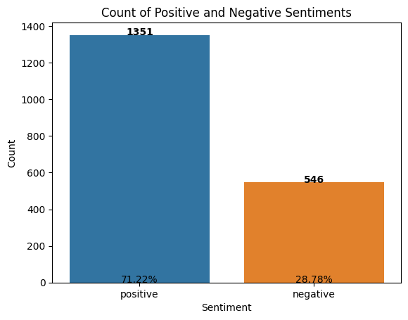

```python
# Count number of positive and negative rows in column "Vader_Sentiment"
positive_rows = (df_cleaned["Vader_Sentiment"] == "positive").sum()
negative_rows = (df_cleaned["Vader_Sentiment"] == "negative").sum()

# Calculate the percentage of each count
total_rows = positive_rows + negative_rows
positive_percent = positive_rows / total_rows * 100
negative_percent = negative_rows / total_rows * 100

# Plot the bar chart
sns.barplot(x=["positive", "negative"], y=[positive_rows, negative_rows])
plt.title("Count of Positive and Negative Sentiments")
plt.xlabel("Sentiment")
plt.ylabel("Count")

# Add the values of each bar to the chart
for i, v in enumerate([positive_rows, negative_rows]):
    plt.text(i, v, str(v), color='black', ha='center', fontweight='bold')

# Add the percentage of each bar to the chart
for i, v in enumerate([positive_percent, negative_percent]):
    plt.text(i, 0, str(round(v, 2)) + "%", color='black', ha='center')

# Show the plot
plt.show()
```

I will now duplicate the rows with the "negative" sentiment such that it is balanced with the "positive" rows

```python
df_smote = pd.DataFrame(df_cleaned)
df_smote
```

|  | Lemmatized_Headlines | POS_Tags | Vader_Sentiment |
| --- | --- | --- | --- |
| 0 | [sequoiaback, defi, app, flint, discontinu, fl... | [(sequoiaback, NN), (defi, NN), (app, NN), (fl... | positive |
| 1 | [dutch, central, bank, fine, cryptocurr, excha... | [(dutch, JJ), (central, JJ), (bank, NN), (fine... | positive |
| 2 | [crypto, worth, fix, regul, get, move] | [(crypto, NN), (worth, JJ), (fix, NN), (regul,... | positive |
| 3 | [cryptocurr, roundup, januari, circl, billion,... | [(cryptocurr, NN), (roundup, NN), (januari, NN... | negative |
| 4 | [cryptocurr, roundup, januari, binanc, process... | [(cryptocurr, NN), (roundup, NN), (januari, NN... | positive |
| ... | ... | ... | ... |
| 2589 | [commod, etf, provid, aim, green, nich] | [(commod, NN), (etf, NN), (provid, NN), (aim, ... | positive |
| 2590 | [lord, make, esg, yet] | [(lord, NN), (make, VBP), (esg, NN), (yet, RB)] | positive |
| 2591 | [ken, griffin, citadel, secur, borrow, mn, tra... | [(ken, VBN), (griffin, JJ), (citadel, NN), (se... | positive |
| 2592 | [u, stock, edg, higher, burst, mix, econom, data] | [(u, JJ), (stock, NN), (edg, NN), (higher, JJR... | positive |
| 2593 | [compani, burnt, record, amount, cash, q] | [(compani, NN), (burnt, NN), (record, NN), (am... | positive |

1897 rows × 3 columns

```python
# Count the number of rows with each sentiment category
sentiment_counts = df_smote['Vader_Sentiment'].value_counts()

# Calculate the number of negative rows to duplicate
num_negatives_to_duplicate = sentiment_counts['positive'] - sentiment_counts['negative']

# If we need to duplicate any negative rows, create a new DataFrame with the duplicates
if num_negatives_to_duplicate > 0:
    negative_rows = df_smote[df_smote['Vader_Sentiment'] == 'negative']
    negative_rows_to_duplicate = negative_rows.sample(n=num_negatives_to_duplicate, replace=True)
    df_smote = pd.concat([df_smote, negative_rows_to_duplicate])

# Calculate the total count of rows and the percentage of each sentiment category
total_count = len(df_smote)
positive_percent = sentiment_counts['positive'] / total_count * 100
negative_percent = sentiment_counts['negative'] / total_count * 100
```

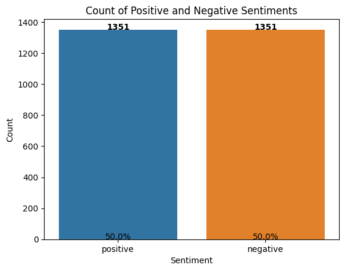

```python
# Count number of positive and negative rows in column "Vader_Sentiment"
positive_rows = (df_smote["Vader_Sentiment"] == "positive").sum()
negative_rows = (df_smote["Vader_Sentiment"] == "negative").sum()

# Calculate the percentage of each count
total_rows = positive_rows + negative_rows
positive_percent = positive_rows / total_rows * 100
negative_percent = negative_rows / total_rows * 100

# Plot the bar chart
sns.barplot(x=["positive", "negative"], y=[positive_rows, negative_rows])
plt.title("Count of Positive and Negative Sentiments")
plt.xlabel("Sentiment")
plt.ylabel("Count")

# Add the values of each bar to the chart
for i, v in enumerate([positive_rows, negative_rows]):
    plt.text(i, v, str(v), color='black', ha='center', fontweight='bold')

# Add the percentage of each bar to the chart
for i, v in enumerate([positive_percent, negative_percent]):
    plt.text(i, 0, str(round(v, 2)) + "%", color='black', ha='center')

# Show the plot
plt.show()
```

```python
df_smote
```

|  | Lemmatized_Headlines | POS_Tags | Vader_Sentiment |
| --- | --- | --- | --- |
| 0 | [sequoiaback, defi, app, flint, discontinu, fl... | [(sequoiaback, NN), (defi, NN), (app, NN), (fl... | positive |
| 1 | [dutch, central, bank, fine, cryptocurr, excha... | [(dutch, JJ), (central, JJ), (bank, NN), (fine... | positive |
| 2 | [crypto, worth, fix, regul, get, move] | [(crypto, NN), (worth, JJ), (fix, NN), (regul,... | positive |
| 3 | [cryptocurr, roundup, januari, circl, billion,... | [(cryptocurr, NN), (roundup, NN), (januari, NN... | negative |
| 4 | [cryptocurr, roundup, januari, binanc, process... | [(cryptocurr, NN), (roundup, NN), (januari, NN... | positive |
| ... | ... | ... | ... |
| 2559 | [compani, attack, texa, politicis, esg, blackl... | [(compani, JJ), (attack, NN), (texa, NN), (pol... | negative |
| 483 | [crypto, crash, market, tourist, purg, say, gl... | [(crypto, NN), (crash, NN), (market, NN), (tou... | negative |
| 1353 | [gemini, resort, third, wave, job, cut, dcg, m... | [(gemini, NN), (resort, NN), (third, JJ), (wav... | negative |
| 2086 | [global, bond, market, take, hit, boj, shock, ... | [(global, JJ), (bond, NN), (market, NN), (take... | negative |
| 167 | [warren, buffett, berkshir, warn, crypto, webs... | [(warren, NNS), (buffett, VBP), (berkshir, NN)... | negative |

2702 rows × 3 columns

## Feature Extraction

To classify the text into any category, we need to define some criteria. On the basis of those criteria, our classifier will learn that a particular kind of text falls in a particular category. This kind of criteria is known as **feature**. We can define one or more feature to train our classifier.

In this example, we will use the **top-N words feature**.

### Frequency distribution of Top 10 Words from 2 dataframes (df_smote)

```python
from itertools import chain
from nltk.probability import FreqDist

df_cleaned_tokens = list(chain(*df_smote['Lemmatized_Headlines'].tolist()))

df_cleaned_frequency = FreqDist(df_cleaned_tokens)

print("Frequency Distribution of Words in df_smote:")
print(df_cleaned_frequency)
print("10 Most Frequently Occurring Words in df_smote:")
print(df_cleaned_frequency.most_common(10))
```

```
Frequency Distribution of Words in df_smote:
<FreqDist with 3238 samples and 21014 outcomes>
10 Most Frequently Occurring Words in df_smote:
[('crypto', 647), ('bitcoin', 387), ('cryptocurr', 350), ('market', 271), ('price', 260), ('top', 227), ('u', 177), ('ftx', 171), ('investor', 168), ('bond', 152)]
```

```python
pip install wordcloud
```

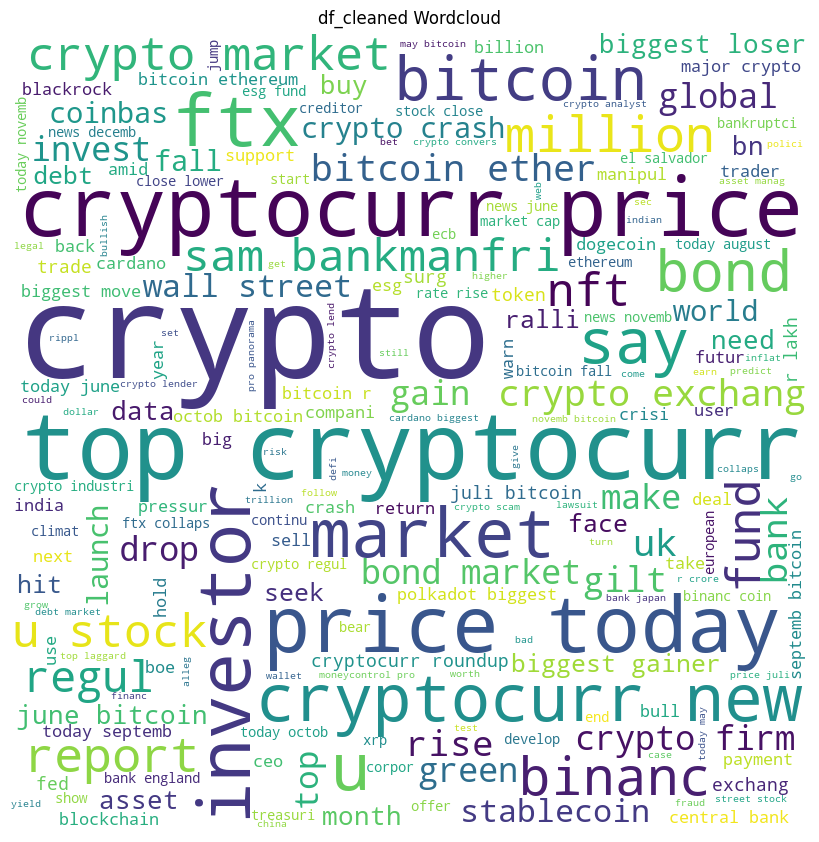

```python
from wordcloud import WordCloud
import matplotlib.pyplot as plt

def plot_wordcloud(words, title):
    stop_words = set(stopwords.words('english'))
    wordcloud = WordCloud(width = 800, height = 800,
                background_color ='white',
                stopwords = stop_words,
                min_font_size = 10).generate(words)

    # plot the WordCloud image
    plt.figure(figsize = (8, 8), facecolor = None)
    plt.imshow(wordcloud)
    plt.axis("off")
    plt.tight_layout(pad = 0)
    plt.title(title)
    plt.show()


df_cleaned_words = ' '.join(df_cleaned_tokens)

plot_wordcloud(df_cleaned_words, 'df_cleaned Wordcloud')
```

## N Grams

Now we are ready to tokenize the sentences, obtain a bag of words and perform topic modeling. n-grams are sometimes very useful for this purpose. They help to extract well-established expressions and understand each topic better. We’ll take ones that are the most frequent among the documents.

### Uni-Gram

```python
# Join all words from the 3 dataframes into a single list
all_words = []
for df in [df_cleaned]:
    all_words += [word for words in df_smote["Lemmatized_Headlines"] for word in words]

# Calculate the frequency of each word in the list
all_words_frequency = FreqDist(all_words)

# Select the 4000 most frequently occurring words
word_features = [word for word, freq in all_words_frequency.most_common(3360)]

# Print the first 10 most frequently occurring words
print("First 10 most frequently occurring words:")
for word in word_features[:10]:
    print(word)

# Print the last 10 most frequently occurring words
print("\nLast 10 most frequently occurring words:")
for word in word_features[-10:]:
    print(word)
```

```
First 10 most frequently occurring words:
crypto
bitcoin
cryptocurr
market
price
top
u
ftx
investor
bond

Last 10 most frequently occurring words:
prefer
gaug
fourweek
commod
nich
lord
ken
griffin
burnt
amount
```

### Bi-Gram

```python
# Join all words from the 3 dataframes into a single list
all_words = []
for df in [df_cleaned]:
    all_words += [word for words in df_smote["Lemmatized_Headlines"] for word in words]

# Generate the bigrams
bigrams = nltk.bigrams(all_words)

# Calculate the frequency of each bigram
bigram_frequency = nltk.FreqDist(bigrams)

# Select the 4000 most frequently occurring bigrams
bigram_features = [bigram for bigram, freq in bigram_frequency.most_common(3360)]

# Print the first 10 most frequently occurring bigrams
print("First 10 most frequently occurring bigrams:")
for bigram in bigram_features[:10]:
    print(bigram)

# Print the last 10 most frequently occurring bigrams
print("\nLast 10 most frequently occurring bigrams:")
for bigram in bigram_features[-10:]:
    print(bigram)
```

```
First 10 most frequently occurring bigrams:
('top', 'cryptocurr')
('cryptocurr', 'price')
('price', 'today')
('cryptocurr', 'news')
('crypto', 'market')
('u', 'stock')
('sam', 'bankmanfri')
('crypto', 'exchang')
('bitcoin', 'ether')
('bond', 'market')

Last 10 most frequently occurring bigrams:
('look', 'blockchain')
('tech', 'help')
('help', 'top')
('mcap', 'top')
('top', 'trillion')
('trillion', 'top')
('green', 'mcap')
('mcap', 'breach')
('breach', 'trillion')
('rise', 'bankmanfri')
```

## Creating feature set

```python
def document_features(df, stemmed_tokens):
    doc_features = []
    for index, row in df.iterrows():
        features = {}
        for word in word_features:
            # get term occurence: true if it's in the word_features, false if it's not
            features[word] = (word in row[stemmed_tokens])
        doc_features.append(features)
    return doc_features

word_features = [word[0] for word in all_words_frequency.most_common(3360)]

df_cleaned_feature_set = pd.DataFrame(document_features(df_smote, 'Lemmatized_Headlines'), index=df_smote.index)
```

```python
df_cleaned_feature_set.head()
```

|  | crypto | bitcoin | cryptocurr | market | price | top | u | ftx | investor | bond | ... | prefer | gaug | fourweek | commod | nich | lord | ken | griffin | burnt | amount |
| --- | --- | --- | --- | --- | --- | --- | --- | --- | --- | --- | --- | --- | --- | --- | --- | --- | --- | --- | --- | --- | --- |
| 0 | False | False | False | False | False | False | False | False | False | False | ... | False | False | False | False | False | False | False | False | False | False |
| 1 | False | False | True | False | False | False | False | False | False | False | ... | False | False | False | False | False | False | False | False | False | False |
| 2 | True | False | False | False | False | False | False | False | False | False | ... | False | False | False | False | False | False | False | False | False | False |
| 3 | True | False | True | False | False | False | False | False | False | False | ... | False | False | False | False | False | False | False | False | False | False |
| 4 | False | True | True | False | False | False | False | False | False | False | ... | False | False | False | False | False | False | False | False | False | False |

5 rows × 3238 columns

```python
import nltk
from nltk.util import ngrams

def document_features_bigrams(df, stemmed_tokens):
    doc_features = []
    for index, row in df.iterrows():
        features = {}
        words = row[stemmed_tokens]
        bigrams = ngrams(words, 2)
        for bigram in bigrams:
            bigram_str = " ".join(bigram)
            features[bigram_str] = (bigram_str in bigrams)
        for word in word_features:
            features[word] = (word in row[stemmed_tokens])
        doc_features.append(features)
    return doc_features


df_cleaned_feature_bigrams_set = pd.DataFrame(document_features_bigrams(df_smote, 'Lemmatized_Headlines'), index=df_smote.index)
```

```python
df_cleaned_feature_bigrams_set.head()
```

|  | sequoiaback defi | crypto | bitcoin | cryptocurr | market | price | top | u | ftx | investor | ... | global scope | manag go | fed prefer | stablecoin issuer | fourweek string | net zero | commod etf | lord make | ken griffin | compani burnt |
| --- | --- | --- | --- | --- | --- | --- | --- | --- | --- | --- | --- | --- | --- | --- | --- | --- | --- | --- | --- | --- | --- |
| 0 | False | False | False | False | False | False | False | False | False | False | ... | NaN | NaN | NaN | NaN | NaN | NaN | NaN | NaN | NaN | NaN |
| 1 | NaN | False | False | True | False | False | False | False | False | False | ... | NaN | NaN | NaN | NaN | NaN | NaN | NaN | NaN | NaN | NaN |
| 2 | NaN | True | False | False | False | False | False | False | False | False | ... | NaN | NaN | NaN | NaN | NaN | NaN | NaN | NaN | NaN | NaN |
| 3 | NaN | True | False | True | False | False | False | False | False | False | ... | NaN | NaN | NaN | NaN | NaN | NaN | NaN | NaN | NaN | NaN |
| 4 | NaN | False | True | True | False | False | False | False | False | False | ... | NaN | NaN | NaN | NaN | NaN | NaN | NaN | NaN | NaN | NaN |

5 rows × 4598 columns

# Data Modelling

## Models we will be using before performing hyper-parameter tuning and more feature extraction & selection

Random Forest: It is an ensemble learning method for classification and regression that uses multiple decision trees to make predictions. The predictions are made by averaging the predictions of individual trees in the forest.

Decision Tree: Decision tree is a tree-like model that is used to solve classification and regression problems.

Naive Bayes Classifier: It is based on Bayes Theorem and considers each feature to be independent of each other. It is often used for text classification.

Logistic Regression: It is a linear model that is commonly used for binary classification problems, including sentiment analysis.

KNeighbors Classifier: It is a non-parametric method used for classification that is based on finding the K nearest neighbors to a given sample and determining the label of the sample based on the majority class among its K nearest neighbors.

XGBoost Classifier: It is an optimized implementation of gradient boosting and is often used for sentiment analysis.

```python
import gensim
from gensim import corpora
from gensim.models import TfidfModel
```

```python
from sklearn.ensemble import RandomForestClassifier
from sklearn.tree import DecisionTreeClassifier
from sklearn.naive_bayes import MultinomialNB
from sklearn.linear_model import LogisticRegression
from sklearn.neighbors import KNeighborsClassifier
from sklearn.ensemble import GradientBoostingClassifier


from sklearn.metrics import classification_report
from sklearn.metrics import accuracy_score, precision_score, recall_score, f1_score, confusion_matrix, ConfusionMatrixDisplay
```

## Training Classifier

From the feature set we created above, we now create a separate training set and a separate testing/validation set. The train set is used to train the classifier and the test set is used to test the classifier to check how accurately it classifies the given text.

### Creating Train and Test Dataset

```python
from sklearn.model_selection import train_test_split
```

```python
# Create the model and append them to the list called models.
models = []

models.append(('KNN', KNeighborsClassifier()))
models.append(('LR', LogisticRegression(solver='liblinear')))
models.append(('DT', DecisionTreeClassifier()))
models.append(('NB', MultinomialNB()))
models.append(('RF', RandomForestClassifier(n_estimators=10)))
models.append(('GB', GradientBoostingClassifier()))
```

```python
x = df_cleaned_feature_set
y = df_smote['Vader_Sentiment']

x_train, x_test, y_train, y_test = train_test_split(x, y, test_size=0.2, random_state=42, stratify=y)
```

```python
print('x_train shape: ', x_train.shape)
print('x_test shape: ', x_test.shape)
print('y_train shape: ', y_train.shape)
print('y_val shape: ', y_test.shape)
```

```
x_train shape:  (2161, 3238)
x_test shape:  (541, 3238)
y_train shape:  (2161,)
y_val shape:  (541,)
```

## Uni-gram modeling

```python
names = []
scores = []
precision = []
recall = []
f1 = []

for name, model in models:
    model.fit(x_train, y_train)
    y_pred = model.predict(x_test)

    f1.append(f1_score(y_test, y_pred, pos_label='positive'))
    recall.append(recall_score(y_test, y_pred, pos_label='positive'))
    precision.append(precision_score(y_test, y_pred, pos_label='positive'))
    scores.append(accuracy_score(y_test, y_pred))
    names.append(name)


uni_models_comparison = pd.DataFrame({'Name': names, 'Score': scores, 'Precision Score': precision, 'Recall': recall, 'F1 Score': f1})
```

```python
uni_models_comparison.sort_values(by='Score', ascending=False)
```

|  | Name | Score | Precision Score | Recall | F1 Score |
| --- | --- | --- | --- | --- | --- |
| 4 | RF | 0.913124 | 0.908425 | 0.918519 | 0.913444 |
| 1 | LR | 0.903882 | 0.925781 | 0.877778 | 0.901141 |
| 2 | DT | 0.896488 | 0.928000 | 0.859259 | 0.892308 |
| 3 | NB | 0.804067 | 0.862832 | 0.722222 | 0.786290 |
| 5 | GB | 0.802218 | 0.743284 | 0.922222 | 0.823140 |
| 0 | KNN | 0.689464 | 0.635638 | 0.885185 | 0.739938 |

From here by using the Uni-gram features, we will take the top 3 best performing models and do hyper-parameter tuning and more feature extraction from the models, which are **Random Forest**, **Logistic Regression** and **Decision Tree**.

The best out of the three models is, Random Forest, which obtained an accuracy score of 91.3%, precision score of 90.8% a recall score of 91.8% and a F1 score of 91.3%

## Bi-gram modeling

```python
from sklearn.feature_extraction.text import CountVectorizer
from sklearn.impute import SimpleImputer

#imputer = SimpleImputer()
#df_cleaned_imputed = imputer.fit_transform(df_cleaned_feature_bigrams_set)

df_cleaned_feature_bigrams_set.fillna(0, inplace=True)
x = df_cleaned_feature_bigrams_set
y = df_smote['Vader_Sentiment']

x_train, x_test, y_train, y_test = train_test_split(x, y, test_size=0.2, random_state=42, stratify=y)


names = []
scores = []
precision = []
recall = []
f1 = []

for name, model in models:
    model.fit(x_train, y_train)
    y_pred = model.predict(x_test)

    f1.append(f1_score(y_test, y_pred, pos_label='positive'))
    recall.append(recall_score(y_test, y_pred, pos_label='positive'))
    precision.append(precision_score(y_test, y_pred, pos_label='positive'))
    scores.append(accuracy_score(y_test, y_pred))
    names.append(name)


bi_models_comparison = pd.DataFrame({'Name': names, 'Score': scores, 'Precision Score': precision, 'Recall': recall, 'F1 Score': f1})
bi_models_comparison.sort_values(by='Score', ascending=False)
```

|  | Name | Score | Precision Score | Recall | F1 Score |
| --- | --- | --- | --- | --- | --- |
| 4 | RF | 0.911275 | 0.911111 | 0.911111 | 0.911111 |
| 1 | LR | 0.903882 | 0.925781 | 0.877778 | 0.901141 |
| 2 | DT | 0.887246 | 0.916335 | 0.851852 | 0.882917 |
| 3 | NB | 0.805915 | 0.866667 | 0.722222 | 0.787879 |
| 5 | GB | 0.796673 | 0.736686 | 0.922222 | 0.819079 |
| 0 | KNN | 0.696858 | 0.646409 | 0.866667 | 0.740506 |

From here by using the Bi-gram features, we will take the top 3 best performing models and do hyper-parameter tuning and more feature extraction from the models, which are **Random Forest**, **Logistic Regression** and **Decision Tree**.

We will conclude to using the **Uni-Gram** model because it has a better model performance than the **bi-gram** model.

## Uni-Gram Classification Report & Confusion Matrix

```
              precision    recall  f1-score   support

    negative       0.90      0.93      0.91       271
    positive       0.92      0.90      0.91       270

    accuracy                           0.91       541
   macro avg       0.91      0.91      0.91       541
weighted avg       0.91      0.91      0.91       541
```

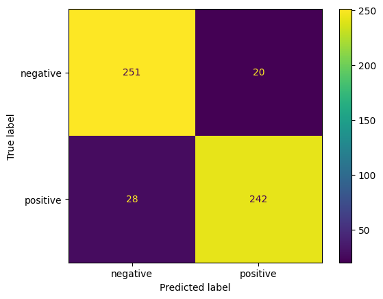

```
Random Forest Accuracy: 0.9113
```

```python
x = df_cleaned_feature_set
y = df_smote['Vader_Sentiment']

x_train, x_test, y_train, y_test = train_test_split(x, y, test_size=0.2, random_state=42, stratify=y)

rf = RandomForestClassifier(n_estimators=10)
rf.fit(x_train, y_train)


rf_preds = rf.predict(x_test)
print(classification_report(y_test, rf_preds))

cm_rf  = confusion_matrix(y_test, rf.predict(x_test), labels=rf.classes_)
disp = ConfusionMatrixDisplay(confusion_matrix=cm_rf,
                              display_labels=rf.classes_)
disp.plot()
plt.show()

accuracy = accuracy_score(y_test, rf_preds)
print("Random Forest Accuracy: {:.4f}".format(accuracy))
```

```
              precision    recall  f1-score   support

    negative       0.88      0.93      0.91       271
    positive       0.93      0.88      0.90       270

    accuracy                           0.90       541
   macro avg       0.90      0.90      0.90       541
weighted avg       0.90      0.90      0.90       541
```

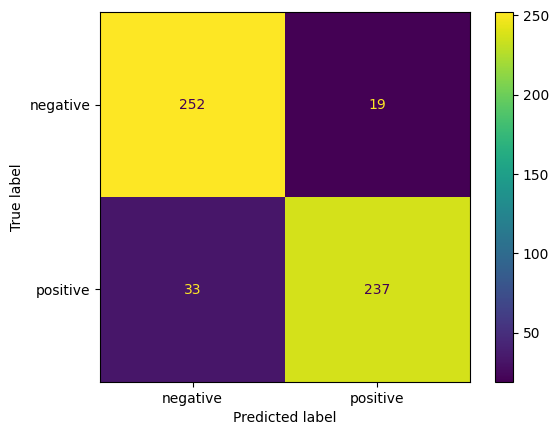

```
Logistic Regression Accuracy: 0.9039
```

```python
x = df_cleaned_feature_set
y = df_smote['Vader_Sentiment']

x_train, x_test, y_train, y_test = train_test_split(x, y, test_size=0.2, random_state=42, stratify=y)

lr = LogisticRegression(solver='liblinear')
lr.fit(x_train, y_train)

lr_preds = lr.predict(x_test)
print(classification_report(y_test, lr_preds))

cm_lr = confusion_matrix(y_test, lr.predict(x_test), labels=lr.classes_)
disp = ConfusionMatrixDisplay(confusion_matrix=cm_lr,
                              display_labels=lr.classes_)
disp.plot()
plt.show()

accuracy = accuracy_score(y_test, lr_preds)
print("Logistic Regression Accuracy: {:.4f}".format(accuracy))
```

```
              precision    recall  f1-score   support

    negative       0.85      0.93      0.89       271
    positive       0.92      0.83      0.87       270

    accuracy                           0.88       541
   macro avg       0.88      0.88      0.88       541
weighted avg       0.88      0.88      0.88       541
```

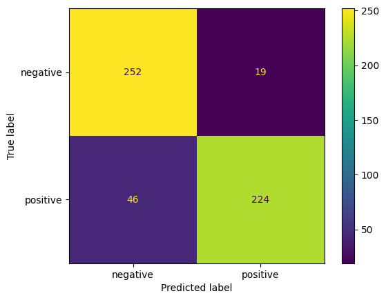

```
Decision Tree Accuracy: 0.8799
```

```python
x = df_cleaned_feature_set
y = df_smote['Vader_Sentiment']

x_train, x_test, y_train, y_test = train_test_split(x, y, test_size=0.2, random_state=42, stratify=y)

dt = DecisionTreeClassifier()
dt.fit(x_train, y_train)

dt_preds = dt.predict(x_test)
print(classification_report(y_test, dt_preds))

cm_dt = confusion_matrix(y_test, dt.predict(x_test), labels=dt.classes_)
disp = ConfusionMatrixDisplay(confusion_matrix=cm_dt,
                              display_labels=dt.classes_)
disp.plot()
plt.show()

accuracy = accuracy_score(y_test, dt_preds)
print("Decision Tree Accuracy: {:.4f}".format(accuracy))
```

```python
df_cm = pd.DataFrame(columns=['Model','TN','FP','TP','FN'])

#fill in dataframe with confusion matrix values
df_cm.loc[0] = ['Logistic Regression', cm_rf[0][0], cm_rf[0][1], cm_rf[1][1], cm_rf[1][0]]
df_cm.loc[1] = ['Random Forest', cm_lr[0][0], cm_lr[0][1], cm_lr[1][1], cm_lr[1][0]]
df_cm.loc[2] = ['Gradient Boosting', cm_dt[0][0], cm_dt[0][1], cm_dt[1][1], cm_dt[1][0]]

#print dataframe
df_cm.sort_values(by='TP', ascending=False)
```

[output not shown]

```python
import string
def process_text(text):

    text = text.lower() # Normalize text to lowercase
    text = text.translate(str.maketrans("", "", string.punctuation)) # Remove punctuation
    text = text.translate(str.maketrans("", "", string.digits)) # Remove digits

    tokens = word_tokenize(text) # Tokenize text
    tokens = [word for word in tokens if word not in stop_words] # Remove stop words
    tokens = pos_tag(tokens) # POS tagging
    tokens = [lemmatizer.lemmatize(token[0], pos='v') for token in tokens] # Lemmatize text
    return tokens
```

```python
classifier = RandomForestClassifier(n_estimators=10)
classifier.fit(x_train, y_train)

data = {'custom_review': ['With the trends of all cryptos going on a rollercoaster with their values, I honestly think crypto is a scam.',
                          'Bitcoin is surging up! Time to make bank!']}

df_test = pd.DataFrame (data, columns = ['custom_review'])
df_test['custom_review'] = df_test['custom_review'].apply(process_text)

df_test.head()
```

|  | custom_review |
| --- | --- |
| 0 | [trend, cryptos, go, rollercoaster, value, hon... |
| 1 | [bitcoin, surge, time, make, bank] |

```python
test_features = pd.DataFrame(document_features(df_test, 'custom_review'), index = df_test.index)
print(test_features.isnull().sum())
test_features.fillna(0, inplace=True)
```

```
crypto        0
bitcoin       0
cryptocurr    0
market        0
price         0
             ..
lord          0
ken           0
griffin       0
burnt         0
amount        0
Length: 3238, dtype: int64
```

```python
print (classifier.predict(test_features))
```

```
['negative' 'positive']
```

## Bag of Words using TF-IDF Feature

Next, we will create the feature set using TF-IDF. We will create a dictionary of unique words and calculate the term weights for the text feature. Below is the function to create Term Frequency features.

```python
import gensim
from gensim import corpora

# Build the dictionary
mydict = corpora.Dictionary(df_smote['Lemmatized_Headlines'])
vocab_len = len(mydict)

def get_bow_features(df, stemmed_tokens):
    bow_features = []
    for index, row in df.iterrows():
        # Converting the tokens into the format that the model requires
        features = gensim.matutils.corpus2csc([mydict.doc2bow(row[stemmed_tokens])],num_terms=vocab_len).toarray()[:,0]
        bow_features.append(features)
    return bow_features

header = ",".join(str(mydict[ele]) for ele in range(vocab_len))

bow_features = pd.DataFrame(get_bow_features(df_smote, 'Lemmatized_Headlines'),
                            columns=header.split(','), index = df_smote.index)
print(df_smote.shape, bow_features.shape)
bow_features.head()
```

```
(2702, 3) (2702, 3238)
```

|  | app | defi | discontinu | flagship | flint | report | sequoiaback | servic | yield | bank | ... | prefer | shortdat | fourweek | commod | nich | lord | griffin | ken | amount | burnt |
| --- | --- | --- | --- | --- | --- | --- | --- | --- | --- | --- | --- | --- | --- | --- | --- | --- | --- | --- | --- | --- | --- |
| 0 | 1.0 | 1.0 | 1.0 | 1.0 | 1.0 | 1.0 | 1.0 | 1.0 | 1.0 | 0.0 | ... | 0.0 | 0.0 | 0.0 | 0.0 | 0.0 | 0.0 | 0.0 | 0.0 | 0.0 | 0.0 |
| 1 | 0.0 | 0.0 | 0.0 | 0.0 | 0.0 | 0.0 | 0.0 | 0.0 | 0.0 | 1.0 | ... | 0.0 | 0.0 | 0.0 | 0.0 | 0.0 | 0.0 | 0.0 | 0.0 | 0.0 | 0.0 |
| 2 | 0.0 | 0.0 | 0.0 | 0.0 | 0.0 | 0.0 | 0.0 | 0.0 | 0.0 | 0.0 | ... | 0.0 | 0.0 | 0.0 | 0.0 | 0.0 | 0.0 | 0.0 | 0.0 | 0.0 | 0.0 |
| 3 | 0.0 | 0.0 | 0.0 | 0.0 | 0.0 | 0.0 | 0.0 | 0.0 | 0.0 | 0.0 | ... | 0.0 | 0.0 | 0.0 | 0.0 | 0.0 | 0.0 | 0.0 | 0.0 | 0.0 | 0.0 |
| 4 | 0.0 | 0.0 | 0.0 | 0.0 | 0.0 | 0.0 | 0.0 | 0.0 | 0.0 | 0.0 | ... | 0.0 | 0.0 | 0.0 | 0.0 | 0.0 | 0.0 | 0.0 | 0.0 | 0.0 | 0.0 |

5 rows × 3238 columns

```python
import gensim
from gensim import corpora
from gensim.models import TfidfModel

# Build the dictionary
mydict = corpora.Dictionary(df_smote['Lemmatized_Headlines'])
vocab_len = len(mydict)
corpus = [mydict.doc2bow(line) for line in df_smote['Lemmatized_Headlines']]
tfidf_model = TfidfModel(corpus)

def get_tfidf_features(df, stemmed_tokens):
    test_features_tfidf = []
    for index, row in df.iterrows():
        doc = mydict.doc2bow(row[stemmed_tokens])
        # Converting the tokens into the format that the model requires
        features = gensim.matutils.corpus2csc([tfidf_model[doc]], num_terms=vocab_len).toarray()[:,0]
        test_features_tfidf.append(features)
    return test_features_tfidf

header = ",".join([str(mydict[ele]) for ele in range(vocab_len)])

tfidf_features = pd.DataFrame(get_tfidf_features(df_smote, 'Lemmatized_Headlines'),
                            columns=header.split(','), index = df_smote.index)
tfidf_features.head()
```

|  | app | defi | discontinu | flagship | flint | report | sequoiaback | servic | yield | bank | ... | prefer | shortdat | fourweek | commod | nich | lord | griffin | ken | amount | burnt |
| --- | --- | --- | --- | --- | --- | --- | --- | --- | --- | --- | --- | --- | --- | --- | --- | --- | --- | --- | --- | --- | --- |
| 0 | 0.297992 | 0.251095 | 0.40442 | 0.40442 | 0.40442 | 0.188461 | 0.40442 | 0.322047 | 0.233874 | 0.000000 | ... | 0.0 | 0.0 | 0.0 | 0.0 | 0.0 | 0.0 | 0.0 | 0.0 | 0.0 | 0.0 |
| 1 | 0.000000 | 0.000000 | 0.00000 | 0.00000 | 0.00000 | 0.000000 | 0.00000 | 0.000000 | 0.000000 | 0.227228 | ... | 0.0 | 0.0 | 0.0 | 0.0 | 0.0 | 0.0 | 0.0 | 0.0 | 0.0 | 0.0 |
| 2 | 0.000000 | 0.000000 | 0.00000 | 0.00000 | 0.00000 | 0.000000 | 0.00000 | 0.000000 | 0.000000 | 0.000000 | ... | 0.0 | 0.0 | 0.0 | 0.0 | 0.0 | 0.0 | 0.0 | 0.0 | 0.0 | 0.0 |
| 3 | 0.000000 | 0.000000 | 0.00000 | 0.00000 | 0.00000 | 0.000000 | 0.00000 | 0.000000 | 0.000000 | 0.000000 | ... | 0.0 | 0.0 | 0.0 | 0.0 | 0.0 | 0.0 | 0.0 | 0.0 | 0.0 | 0.0 |
| 4 | 0.000000 | 0.000000 | 0.00000 | 0.00000 | 0.00000 | 0.000000 | 0.00000 | 0.000000 | 0.000000 | 0.000000 | ... | 0.0 | 0.0 | 0.0 | 0.0 | 0.0 | 0.0 | 0.0 | 0.0 | 0.0 | 0.0 |

5 rows × 3238 columns

## Training Classifier and Calculating Accuracy

We test the classifier again using the TF-IDF feature set.

```python
X = tfidf_features

X_train, X_test, y_train, y_test = train_test_split(X, y, test_size=0.2, random_state=42, stratify=y)

names = []
scores = []
precision = []
recall = []
f1 = []

for name, model in models:
    model.fit(X_train, y_train)
    y_pred = model.predict(X_test)

    f1.append(f1_score(y_test, y_pred, pos_label='positive'))
    recall.append(recall_score(y_test, y_pred, pos_label='positive'))
    precision.append(precision_score(y_test, y_pred, pos_label='positive'))
    scores.append(accuracy_score(y_test, y_pred))
    names.append(name)


models_comparison_tfidf = pd.DataFrame({'Name': names, 'Score': scores, 'Precision Score': precision, 'Recall': recall, 'F1 Score': f1})
```

```python
# After tuning to Bag of Words & TF-IDF Features
models_comparison_tfidf.sort_values(by='Score', ascending=False)
```

|  | Name | Score | Precision Score | Recall | F1 Score |
| --- | --- | --- | --- | --- | --- |
| 2 | DT | 0.887246 | 0.916335 | 0.851852 | 0.882917 |
| 1 | LR | 0.885397 | 0.890977 | 0.877778 | 0.884328 |
| 4 | RF | 0.879852 | 0.881041 | 0.877778 | 0.879406 |
| 3 | NB | 0.804067 | 0.872727 | 0.711111 | 0.783673 |
| 5 | GB | 0.791128 | 0.727536 | 0.929630 | 0.816260 |
| 0 | KNN | 0.731978 | 0.772926 | 0.655556 | 0.709419 |

```python
# Only using N-Grams(Bi-Gram) & POS Tagging
uni_models_comparison.sort_values(by='Score', ascending=False)
```

|  | Name | Score | Precision Score | Recall | F1 Score |
| --- | --- | --- | --- | --- | --- |
| 4 | RF | 0.913124 | 0.908425 | 0.918519 | 0.913444 |
| 1 | LR | 0.903882 | 0.925781 | 0.877778 | 0.901141 |
| 2 | DT | 0.896488 | 0.928000 | 0.859259 | 0.892308 |
| 3 | NB | 0.804067 | 0.862832 | 0.722222 | 0.786290 |
| 5 | GB | 0.802218 | 0.743284 | 0.922222 | 0.823140 |
| 0 | KNN | 0.689464 | 0.635638 | 0.885185 | 0.739938 |

We can see that after implementing the Bag of Words and TF-IDF feature to the model, the Random Forest model loses 3%+ of it's accuracy score.

# Evaluation & Hyperparameter tuning

## Tuning the random-forest model

We will use the same custom review and check the classification output of this new classifier. The classifier correctly predicts both negative and positive reviews provided.

We will perform the test using the Random Forest model.

```python
from sklearn.model_selection import GridSearchCV
from sklearn.model_selection import RandomizedSearchCV
```

```python
# Hyperparameter Tuning

# Define the parameter grid for the Random Forest classifier
param_grid = {
    'max_depth': [None, 10, 15, 20, 30],
    'min_samples_split': [2, 5, 10],
    'min_samples_leaf': [1, 2, 4],
    'criterion': ['gini', 'entropy']
}

cv = GridSearchCV(estimator=RandomForestClassifier(), param_grid=param_grid, cv=7, n_jobs=-1)
cv.fit(x_train, y_train)

print("Best Parameters:", cv.best_params_)
print("Best Score:", cv.best_score_)
```

```
Best Parameters: {'criterion': 'entropy', 'max_depth': None, 'min_samples_leaf': 1, 'min_samples_split': 2}
Best Score: 0.9343069089948425
```

```
              precision    recall  f1-score   support

    negative       0.93      0.92      0.92       271
    positive       0.92      0.93      0.92       270

    accuracy                           0.92       541
   macro avg       0.92      0.92      0.92       541
weighted avg       0.92      0.92      0.92       541
```

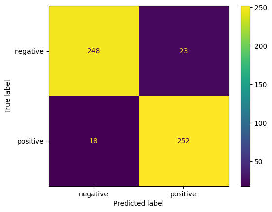

```
Logistic Regression Accuracy: 0.924
```

```python
x = df_cleaned_feature_set
y = df_smote['Vader_Sentiment']

x_train, x_test, y_train, y_test = train_test_split(x, y, test_size=0.2, random_state=42, stratify=y)


rf_final = RandomForestClassifier(**cv.best_params_)
rf_final.fit(x_train, y_train)

rf_final_preds = rf_final.predict(x_test)
print(classification_report(y_test, rf_final_preds))

cm_rf_final = confusion_matrix(y_test, rf_final.predict(x_test), labels=rf_final.classes_)
disp = ConfusionMatrixDisplay(confusion_matrix=cm_rf_final,
                              display_labels=rf_final.classes_)
disp.plot()
plt.show()

accuracy = accuracy_score(y_test, rf_final_preds)
print("Logistic Regression Accuracy: {:.3f}".format(accuracy))
```

```python
# BEFORE HYPER-PARAMETER TUNING
uni_models_comparison.sort_values(by='Score', ascending=False).head(1)
```

|  | Name | Score | Precision Score | Recall | F1 Score |
| --- | --- | --- | --- | --- | --- |
| 4 | RF | 0.913124 | 0.908425 | 0.918519 | 0.913444 |

```python
# AFTER HYPER-PARAMETER TUNING
report = classification_report(y_test, rf_final_preds, output_dict=True)

positive_report = {k:v for (k,v) in report.items() if k == 'positive'}

df_score = pd.DataFrame(positive_report).transpose()
df_score.rename(index={'positive':'RF_AFTER_TUNING'}, inplace=True)
df_score
```

|  | f1-score | precision | recall | support |
| --- | --- | --- | --- | --- |
| RF_AFTER_TUNING | 0.924771 | 0.916364 | 0.933333 | 270.0 |

F1-score is the harmonic mean of precision and recall, providing a balanced metric that takes into account both precision and recall. The F1-score for both negative and positive classes increased after tuning, resulting in a balanced score of 0.92.

The support metric represents the number of instances in each class. In this case, there were 271 instances in the negative class and 270 instances in the positive class.

The overall accuracy score of the model increased from 0.913124 to 0.924 after hyperparameter tuning, which means that the model correctly classified 92.4% of the instances in the test set.

```python
data = {'new_review': ['With the trends of all cryptos going on a rollercoaster with their values, I honestly think crypto is a scam.',
                          'Bitcoin is surging up! Time to make bank!']}

df_test = pd.DataFrame (data, columns = ['new_review'])
df_test['new_review'] = df_test['new_review'].apply(process_text)

df_test.head()
```

|  | new_review |
| --- | --- |
| 0 | [trend, cryptos, go, rollercoaster, value, hon... |
| 1 | [bitcoin, surge, time, make, bank] |

```python
rf_final = RandomForestClassifier(**cv.best_params_)
rf_final.fit(x_train, y_train)


#test_features = pd.DataFrame(get_tfidf_features(df_test, 'new_review'),
                            #columns=header.split(','), index = df_test.index)

test_features = pd.DataFrame(document_features(df_test, 'new_review'), index = df_test.index)
print(test_features.isnull().sum())
test_features.fillna(0, inplace=True)
```

```
crypto        0
bitcoin       0
cryptocurr    0
market        0
price         0
             ..
lord          0
ken           0
griffin       0
burnt         0
amount        0
Length: 3238, dtype: int64
```

```python
print (rf_final.predict(test_features))
```

```
['negative' 'positive']
```

```python
importances = list(classifier.feature_importances_)
feature_importances = [(feature, round(importance, 10)) for feature, importance in zip(tfidf_features.columns, importances)]
feature_importances = sorted(feature_importances, key = lambda x: x[1], reverse = True)

top_i = 0
for pair in feature_importances:
    print('Variable: {:10} Importance: {}'.format(*pair))
    if top_i == 20:
        break
    top_i += 1
```

```
Variable: crypto     Importance: 0.0263067805
Variable: derail     Importance: 0.0144928336
Variable: gain       Importance: 0.0122332491
Variable: top        Importance: 0.0114801578
Variable: employe    Importance: 0.0113874336
Variable: biggest    Importance: 0.0104116855
Variable: blockfi    Importance: 0.0085656399
Variable: shiba      Importance: 0.0078659
Variable: robot      Importance: 0.0075235502
Variable: custodi    Importance: 0.0074089524
Variable: ethereum   Importance: 0.0072150622
Variable: wef        Importance: 0.0070952983
Variable: report     Importance: 0.006972832
Variable: rise       Importance: 0.0067150327
Variable: app        Importance: 0.0065236739
Variable: collabor   Importance: 0.0059692681
Variable: access     Importance: 0.0058417711
Variable: regulatorrequir Importance: 0.0058085901
Variable: launch     Importance: 0.0057196903
Variable: tax        Importance: 0.0052318127
Variable: winter     Importance: 0.0049317516
```

The feature importance of a random forest model provides information on the importance of each feature in the classification task. The importance of each feature is calculated based on how much the tree nodes that use that feature reduce impurity on average.

Overall, the feature importance analysis provides valuable insights into the classification task and can be used to guide further investigation into the factors that contribute to sentiment classification.